# LeBron James - Player Statistics for NBA Season 2005-06

Nuray Nasib & Aymir Aydinli

08 June, 2022

# LeBron James

LeBron James, (born Dec. 30, 1984, Akron, Ohio, U.S.), U.S. basketball player. A basketball prodigy, he was the consensus national high-school player of the year in 2003. He subsequently was selected first overall by the Cleveland Cavaliers in the 2003 NBA draft. James quickly established himself as one of the league’s dominant players. He was named Rookie of the Year in 2004 and later won multiple Most Valuable Player awards (2009, 2010, 2012, and 2013). After the 2009–10 season he signed with the Miami Heat, and he helped the franchise win championships in 2012 and 2013. He returned to the Cavaliers in 2014 and guided the team to its first NBA title in 2016. Two years later he joined the Los Angeles Lakers and helped them capture the championship in 2020. James also was a member of the U.S. Olympic basketball teams that won the bronze medal in 2004 and gold medals in 2008 and 2012. [Source: Brittanica](https://www.britannica.com/biography/LeBron-James).

[figure not shown]

# NBA Season 2005-06 summary in numbers

## Basic Numbers

The data used in this statistic report is available at [Kaggle](https://www.kaggle.com/datasets/justinas/nba-players-data). In the 2005-06 season of NBA LeBron James was 21 years old, weighed 108.86208 pounds and had a height of 203.2 cm. He played for the team CLE and his salary was 4.621.800$. Let’s begin with, probably, the most basic and important basketball stats: points, rebounds and assists. Table below shows average number of points scored, average number of rebounds grabbed, average number of assists distributed respectively by LeBron James in the season;

| Indicators | Stats |
| --- | --- |
| Points | 31.4 |
| Rebounds | 7.0 |
| Assists | 6.6 |

According to the table above, average points scored was 31.4, average number of rebounds grabbed was 7, average number of assist distributed was 6.6.

We would like to present how he was doing compared to league leaders in points and assists numbers in corresponding season. Let’s start with points;

|  | Player | League Leaders Points |
| --- | --- | --- |
| 2005-06 | Kobe Bryant | 35.4 |

In the season 2005-06 the league leader was Kobe Bryant with points per game totaling to 35.4. Whereas LeBron James’ points per game was 31.4. The difference was -4

|  | Player | League Leaders Assists Per Game |
| --- | --- | --- |
| 2005-06 | Steve Nash | 10.46 |

In the season 2005-06 the league leader was Steve Nash with assists per game totaling to 10.46. Whereas LeBron James’ assist per game was 6.6. The difference was -3.86

In the table below we would like to give place to other important and interesting basketball player statistics. These include;

| **Term** | Explanation |
| --- | --- |
| **Net Rating** | Team’s point differential per 100 possessions while the player is on the court |
| **Offensive Rebound Percentage** | Percentage of available offensive rebounds the player grabbed while he was on the floor |
| **Shooting Efficiency** | Measure of the player’s shooting efficiency that takes into account free throws, 2 and 3 point shots |

|  | Net Rating | Offensive Rebound Percentage | Defensive Rebound Percentage | Shooting Efficiency |
| --- | --- | --- | --- | --- |
| 2005-06 | 4.2 | 0.026 | 0.171 | 56.80% |

According to the table, in the season of 2005-06 James’ net rating was 4.2, offensive rebound percentage was 0.026, defensive rebound percentage was 0.171. Out of all the attempts to score a point he succeed in 56.80% of them.

## Line Graph Over the Years

Let’s see how LeBron James’ points changed over the last 10 seasons in the line graph below;

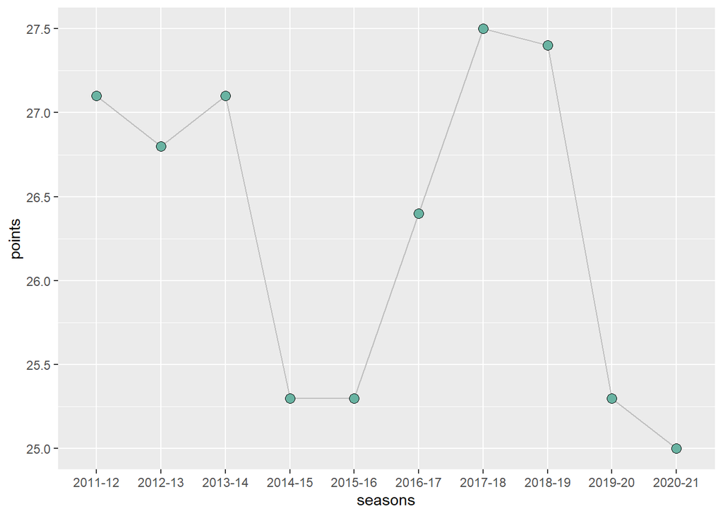

We can see that in the last 10 seasons James’ peak was in season 2017-18 with total points of 27.5 and his lowest was in the season 2020-21 with 25.0 points.

## LeBron James Career Shot Chart by Season

A shot chart is a sort of visualization used in the NBA that allows coaches and players to identify the strong and weak parts of a player’s game–shooting in particular. They provide coaches a sense of how effective a player’s offensive is at getting shots in a specific region. Coaches can develop plays based on where players are making the most shots using frequency analytics, allowing them to be used more efficiently in a game.

A shot chart is made up of two parts or layers. The first layer (at the bottom) is an image of a basketball court drawing (typically, half court). A scatterplot of shot locations is displayed on top of the court. When these two intersect, we may perceive the shots as dots on a basketball half court.

While a shot chart is intended to emphasize a player’s skills, it also identifies some of the gaps in player’s game. A shot chart shows the same quantity of bad and good, and this can be a point of concentration and learning during player development.

Data source for this part is NBA API. The NBA API (application programming interface) provides a wide range of data and player information. This data is the result of some of the most cutting-edge technology in player tracking and information management, which offers a solid foundation for how the NBA and teams collect information.

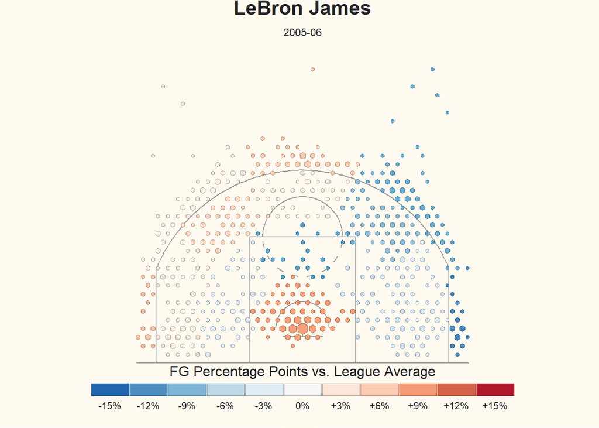

The shot chart represents LeBron James’ Field Gold (FG) Percentage Points vs. League Average for each season. Red dots mean that LeBron James shoots better than the league average from that zone. Grey dots mean James shoots comparable to the league average from that zone. Blue dots mean James shoots worse than the league average from that zone.

# Documentation and Systems Used

**Systems used:**

- Windows 11 Home Version 21H2
- RStudio Version 1.4.1106
- RMarkdown

**Libraries needed to reproduce this file:**

- kableExtra
- ggplot2
- dplyr
- hrbrthemes
- tidyverse
- hexbin
- jsonlite
- httr
- scales
- prismatic
- extrafont
- cowplot
- rmarkdown
- rjson
- Strings